# ddPCR

Sat Jan 04

# Inference

- At some point, sometimes from the very beginning, but more wisely after absorbing what we can learn from this one dataset, we will want to think about making inference to future data.
- At that point we need to consider some statistical framework.
- Giving the classical concepts a new look, Yu and Kumbier (2018) [1] write

> Artificial intelligence (AI) is intrinsically data-driven. It calls for the application of statistical concepts through human-machine collaboration during generation of data, development of algorithms, and evaluation of results. This paper discusses how such human-machine collaboration can be approached through the statistical concepts of population, question of interest, representativeness of training data, and scrutiny of results (PQRS).[^1].
- With the data we are studying here, we also need to think of PQRS:
  - where do the data come from?
  - what sampling mechanism can we assume to be not too implausible?
  - what generalizations can we entertain?
- We have more than one run so that inference to other runs is possible, but these other runs would be just like the ones in this data set.
  - ie. we can make statistical inference to a hypothetical larger (ie. population) dataset, or to future datasets of the same sort
  - beyond the hypothetical population from which the study dataset was drawn, there is no statistical inference possible, but generalizability can be postulated if there is ground to do so.

## Parameter Setting

```r
params <- list(

 # Dorazio
 Dorazio_2015_supp_dir = "../Refs/Dorazio_2015_supp",
 Dorazio_dilution_file = "dilutionData.csv",
 Dorazio_CNV_file = "BioRadData-CNV.csv",
 Dorazio_geneExpress_file = "geneExpressData.csv",


 analysis_Prefix  = FALSE,

 empty = "Last Spot"
)
```

Table 0.1: Input Parameters

| param_name | param_value | param_class |
| --- | --- | --- |
| Dorazio_2015_supp_dir | ../Refs/Dorazio_2015_supp | character |
| Dorazio_dilution_file | dilutionData.csv | character |
| Dorazio_CNV_file | BioRadData-CNV.csv | character |
| Dorazio_geneExpress_file | geneExpressData.csv | character |
| analysis_Prefix | FALSE | logical |
| empty | Last Spot | character |

# 1 The ddPCR Platform

- The results of the simulations show that the binomial model does not lead to appropriate estimated standard errors - ie. confidence intervals computed based on these SEs do not have the correct coverage frequencies.
  - Return to this later

## 1.1 ddPCR Bibliography

### First pass

- Basu (2017) [2], Whale et al (2013) [17], Kreutz et al (2011) [4], Pinheiro et al (2012) [3], and Dube et al (2008) [5] all discuss some statistical aspects of ddPCR data.
  - Basu’s Partitioning Statistics is reproduced in Section 1.2.
  - Dube derives a mathematical framework to calculate the true concentration of molecules from the observed positive reactions in a panel and find the 95% confidence intervals of the true concentrations and the ratio of two concentrations in a CNV experiment using the digital array with multiplex PCR.
- From BioRad
  - [Qx600 Droplet Digital PCR System](https://www.bio-rad.com/sites/default/files/2023-08/Bulletin_3557.pdf)
    - Absolute Quant with 0.1% sensitivity = 1/1000 droplets
  - [QX600 AutoDG Droplet Digital PCR System](https://www.bio-rad.com/en-us/product/qx600-autodg-droplet-digital-pcr-system?ID=0d9e49a4-cf92-f9a9-5779-ef412180f1ed)
- Pinheiro et al. (2012) [3] is a showcase article written jointly by the National Measurement Institute of Australia and Bio-Rad.
  - Experimental data from independent sets (such as independent gravimetric dilutions) and replicate measurements was combined using the pooled relative standard deviations:

$$\frac{SD_{M_{prec}}}{\bar{M}} = \sqrt{\frac{\left(\frac{SD{M_1}}{M_1}\right)^2(n_1-1)+
\dotsb + \left(\frac{SD{M_L:1}}{M_L}\right)^2(n_L-1)}{n_1 + n_2 + \dotsb + n_L - L}}$$

- similartly for CNR (copy number ratio SD)
- The relative standard uncertainty of the precision data was then determined by dividing the pooled relative standard deviation by the square root of the number of data sets as shown in eqs 6 and 7, respectively:

$$\begin{equation}
\frac{u_{M_\text{prec}}}{\bar{M}} = \frac{SD_{M_\text{prec}}}{\bar{M} \sqrt{i}}
\end{equation}$$

- Quan et al (2018) [18]
  - compares the fundamental concepts behind the quantification of nucleic acids by dPCR and quantitative real-time PCR (qPCR).
  - provides some **detail the underlying statistics of dPCR** and explains how it defines its precision and performance metrics and discuss design decicions relating to droplet size and number.
  - discusses hoe to determine whether the theoretical advantages of dPCR over qPCR hold true by pursuing studies that directly compare assays implemented with both methods.
- Taylor (BioRad) et al (2017) [19]
  - Droplet Digital PCR (ddPCR) and qPCR platforms are directly compared for gene expression analysis using low amounts of purified, synthetic DNA in well characterized samples under identical reaction conditions.
  - for sample/target combinations with low levels of nucleic acids (Cq ≥ 29) and/or variable amounts of chemical and protein contaminants, ddPCR technology will produce more precise and reproducible results
- main difference ddPCR vs qPCR:
  - partitioning of the PCR reaction into thousands of individual reaction vessels
  - acquisition of data at reaction end point
  - Experimental design
    - A single reaction mix was for each sample and for all experiments which was split (20 μL each) for data acquisition
- Stephens et al (2018) [20]
  - Describes a Droplet Digital PCR (ddPCR) protocol and a bioinformatic solution for the detection of contamination in patient’s samples and derived sequencing data, which are based on the same principle:
    - detection of alternative alleles for single-nucleotide polymorphisms (SNPs) that are homozygous according to the control (germline) sample.
- Attali et al (2016), Brink et al (2018) [21,22]
  - Two R packages
    - [ddpcr](https://cran.r-project.org/web/packages/ddpcr/vignettes/overview.html)
    - [ddPCRclust](https://www.bioconductor.org/packages/release/bioc/html/ddPCRclust.html)

## 1.2 Partitioning Statistics

Partitioning statistics are the basis of ddPCR data analysis. Basu et al. (2017) [2] provide a comprehensive introduction to the topic which is summarized below.

### Home

### 1.2.1 PS Fundamentals

- In this section we summarize the fundamentals of Partitioning Statistics presented in Basu et al. (2017) [2]. These remarks are applicable to the context of measuring a single analyte held in solution at a fixed concentration.

```r
knitr::include_graphics("img/Quan_2018_fig_3.png")
```

[output not shown]

- Let
  - m = total number of targets in the sample
  - C = sample concentration = $\frac{m}{\text{units of Volume}}$
  - n = number of partitions or droplets
  - $V_p$ = partition volume
  - $V_s$ = sample volume
  - $\lambda$ = expected number of targets per partition
- In digital assays, the number of targets in the sample (**m**) is typically less than or on the order of the number of partitions (**n**). and there is significant statistical variation in the number of molecules per partition.
  - in what follows we asssume the all partitoions have the same size which gives rise to the `1/n` term in the equations.
- The **average number of targets per partition** ($\lambda$) depends on the sample concentration (C), the number of partitions (n) and sample volume. The following equalities hold:

$$\begin{equation}
\lambda = \frac{m}{n}
\tag{1.1}
\end{equation}$$

$$\begin{equation}
m = C \cdot V_s
\tag{1.2}
\end{equation}$$

$$\begin{equation}
V_p = V_s/n
\tag{1.2}
\end{equation}$$

where $V_s$ is the sample volume and $V_p$ is the targeted partition volume (which will have some variability).

$$\lambda = C \cdot V_p$$

- Finally, to estimate concentration:

$$\begin{equation}
C = \frac{\lambda}{V_p}
\tag{1.3}
\end{equation}$$

- To get at the distribution of the number targets per partition, we note that by definition when partitioning is done at random, each target can be assigned to each partition with equal probability and the assigments are independent between targets.
- For a fixed partition, the probability that `k` targets were assigned to that partition is given by the binomial distribution with `p = 1/n` and `N = m`:

$$\begin{equation}
p(k) = \binom{m}{k} \left(\frac{1}{n}\right)^k
\left(1 - \frac{1}{n}\right)^{m-k}
\tag{1.4}
\end{equation}$$

$$p(k) = \binom{m}{k} \left(\frac{\lambda}{m}\right)^k
\left(1 - \frac{\lambda}{m}\right)^{m-k}$$

The second parametrization is used to emphasize the relationship with the mean number of tatgets per droplet, **$\lambda$**, and the total number of targets, **m**.

- The binomial paremeters are `p = 1/n`, which is small, and `N = m`, which is large, so that the binomial distibution given by (1.4) is well approximated by a Poisson distributoion with parameter $\lambda = E(X) = N \cdot p = m/n$:

$$p(k) = \frac{\lambda^k e^{-\lambda}}{k!}$$

with mean and variance both equal to $\lambda$.

- Let E denote an empty partition[^2]:

$$E = p(0) = e^{-\lambda}$$

So that $\displaystyle \lim_{\lambda \to \infty} E = 0$. In other words, quantitation becomes impossible when $\lambda$ gets to be too large.

- From $\lambda = -ln(E)$, putting $\lambda \approx m/n$ and $E \approx c/n$ where $c$ is the number of observed empty partitions, we have:

$$\begin{equation}
m = n\lambda = -n \cdot ln(E) \\
m \approx n \cdot (ln(n) - ln(c)) \\
c \ge 1 \Longleftrightarrow m < n \cdot ln(n)
\tag{1.5}
\end{equation}$$

- In other words, to statistically have at least one empty partition, the number of targets must be less than $n \cdot ln(n)$.
- Substituting `-ln(E)` for $\lambda$ in Equation (1.3) yields this result:

$$\begin{equation}
C = - \frac{ln(E)}{V_p}
\tag{1.6}
\end{equation}$$

### 1.2.2 Sources of Error

The modeling and analysis of ddPCR data must properly account for the known sources of variability:

- variability due to subsampling from the source sample (donor tube, for example)
  - we can only observe this with replicated subsamplings. ie. draw several aliquots from the source
- variability due to the random allocation of targets to partitions which has two sources of variability:
  - targets are randomly allocated to a bin or partition
  - the bin size may differ from bin to bin

#### Home

#### Subsampling Error

$$\begin{equation}
u_s = z_c \frac{\sigma_m}{m} = z_c \frac{\sqrt{m}}{m} = \frac{z_c}{\sqrt{m}}
\tag{1.7}
\end{equation}$$

- We can estimate the subsampling variability from the estimate for m, if subsampling is like selecting targets at random from a large set.
- Subsampling variability can also be estimated from replicates of the right sort, ie. resample the tube or source

#### Partitioning Error

- In a set of replicate experiments, there is a variance in the number of empty partitions E that propagates to a corresponding variance in the calculated concentration, $\lambda$.
- $\sigma_E = \sqrt{E(1-E)/n}$
- The normalized uncertainty due to partitioning is given by

$$\begin{align}
u_p & = \frac{\Delta m}{m} \\
& = \frac{n(\lambda_{max} - \lambda_{min})}{\lambda n} \\
& = \frac{1}{\lambda} ln \left( \frac{E + z_c \sigma_E}{E - z_c \sigma_E}\right)
\tag{1.8}
\end{align}$$

#### Partition Volume Error

See Pinheiro et al. (2012) [3] for a discussion of partition volumes variability. - 1. It’s complicated - 2. In the data the were analyzed, the partition volume variability can be ignored.

$$\begin{equation}
u = C \sqrt{ (u_p)^2 + \left(\frac{u_{V_d}}{\bar{V_d}}\right)}
\tag{1.9}
\end{equation}$$

- Here, $\bar{V_d}$ is the mean partition volume and C is a coverage factor between 2.05 to 2.18, which *provides a 95% confidence level that the measurement falls within the calculated uncertainty*[^3].
- As the number of partitions is increased from $10^2$ to $10^5$, $u_p$ becomes insignificant, and the expanded uncertainty drops from >10% to about 1%.
- Beyond this, error bars are limited by uncertainty in the partition volume.

```r
knitr::include_graphics("img/Basu_2017_fig3.png")
```

[output not shown]

```r
knitr::include_graphics("img/Basu_2017_fig4.png")
```

[output not shown]

## 1.3 Simulating Partitionings

### Home

### Background

- The assumed binomial variability is used as a model to explain the variability in the occurence of empty partitions, the key measure in ddPCR.
- It is based on the assumption that targets are binned or partitioned at random. We can simulate this context by distributing `m targets` over a unit interval using a uniform distribution to select the target locations on the interval, and overlaying a bin grid over the interval.
- Let
  - N = 10K - the number of partitions
  - $V_s$ = 10K - the sample number of units of volume (same as N for convenience)
  - Conc = .1, .01, .001
- In this context, m is fixed and the only variability is in the partitioning which we assume either has no volume variability, or varies by v = 5, 10 or 20%
  - instead of uniform, make the distribution have density (this only controls the occurence of volium values +/- v%):

$$f(x) = 1 - v/2 + v \cdot x \text{ for x in [0, 1]}$$

### No Volume Variability

#### Home

#### 1.3.0.1 Conc = 0.1

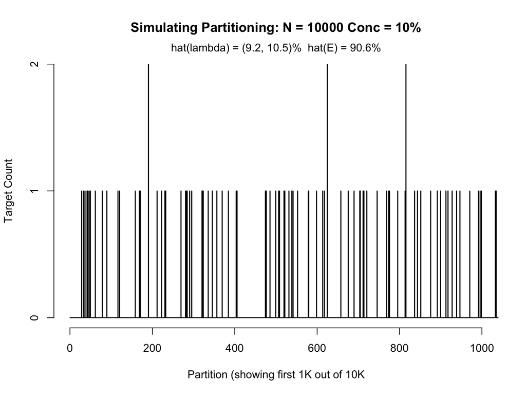

Figure 1.1: No Volume Variability, Conc =10%

```r
 # draw N
Conc = CONC
n_pos <- runif(n=N*Conc) * N
Conc_hist <- hist(n_pos, breaks=seq(from=0, to = N, len = N),main='', plot=F,
        ylab="Target Count", xlab = "Partition")

 # THIS IS NOT ENOUGH VARIABILITY
 # n_pos <- runif(n=N*Conc) * N

 # Should incorporate the subsampling variability
 # N is partition and sample size
 n_target <- rpois(n=1, lambda = N)
 n_pos <- runif(n=n_target*Conc) * N
 Conc_hist <- hist(n_pos, breaks=seq(from=0, to = N, len = N), plot=F)

#empty_ndx <- which(Conc_hist$counts==0)
#rug(empty_ndx, col="red")

#table(Conc_hist$counts)


E_hat <- mean(Conc_hist$counts == 0)
E_low <- E_hat - 2 * sqrt(E_hat * (1 - E_hat)/N)
E_hi <- E_hat + 2 * sqrt(E_hat * (1 - E_hat)/N)

lambda_hat <- - log(E_hat)
lambda_low <- - log(E_hi)
lambda_hi <- - log(E_low)

M_est <-  - N * log(E_hat)

plot(Conc_hist, main='',  ylab="Target Count", xlab = "Partition (showing first 1K out of 10K",
    xlim=c(1, 1000))

title(paste0("Simulating Partitioning: N = ", N, " Conc = ", 100*CONC, '%'))
mtext(side = 3, paste0(expression(hat(lambda)),  ' = (',
  round(100*lambda_low,1), ', ', round(100*lambda_hi,1), ')%',
  "  hat(E) = ", round(100*E_hat, 1), '%'))
```

```r
set.seed(101)
novolvar_conc_0p1_frm <- do.call("rbind", lapply(1:5000,
function(K)
{
 # THIS IS NOT ENOUGH VARIABILITY
 # n_pos <- runif(n=N*Conc) * N

 # Should incorporate the subsampling variability
 # N is partition and sample size
 n_target <- rpois(n=1, lambda = N)
 n_pos <- runif(n=n_target*Conc) * N
 Conc_hist <- hist(n_pos, breaks=seq(from=0, to = N, len = N), plot=F)


 #empty_ndx <- which(Conc_hist$counts==0)
 #rug(empty_ndx, col="red")

 #table(Conc_hist$counts)

 E_hat <- mean(Conc_hist$counts == 0)
 E_low <- E_hat - 2 * sqrt(E_hat * (1 - E_hat)/N)
 E_hi <- E_hat + 2 * sqrt(E_hat * (1 - E_hat)/N)

 lambda_hat <- - log(E_hat)
 lambda_low <- - log(E_hi)
 lambda_hi <- - log(E_low)

  # Interval according to ddPCR_ENGL_2019
  n_tot <- length(Conc_hist$counts)
  n_neg <- sum(Conc_hist$counts == 0)
  n_pos <- n_tot - n_neg
  lambda_low2 <- lambda_hat - 2 * sqrt(n_pos/(n_tot*n_neg))
  lambda_hi2 <- lambda_hat + 2 * sqrt(n_pos/(n_tot*n_neg))


 data.frame(sim=K, E_hat = E_hat, E_low, E_hi, lambda_hat, lambda_low, lambda_hi,
      lambda_low2, lambda_hi2)
}))
```

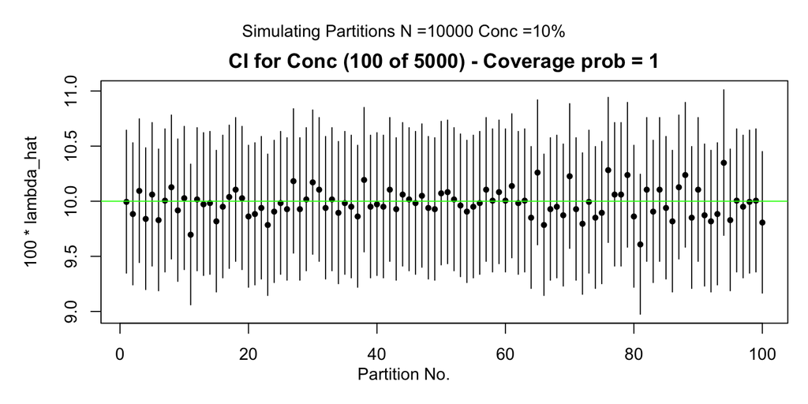

Figure 1.2: No Volume Variability, Conc =10%

```r
par(mfrow=c(1,1), mar=c(2, 5, 2, 1),oma=c(2,0,2,0))

with(novolvar_conc_0p1_frm[1:100,],
{
plot(1:100, 100*lambda_hat, pch=20, ylim = c(min(100*lambda_low), max(100*lambda_hi)), xlab="")
segments(x0=1:100, x1=1:100, y0=100*lambda_low, y1=100*lambda_hi)
abline(h=100*Conc, col='green')
}
)
lambda_coverage_prob <- with(novolvar_conc_0p1_frm,
mean(lambda_low < Conc & Conc < lambda_hi))

title(paste("CI for Conc (100 of 5000) - Coverage prob =",
   round(lambda_coverage_prob, 2)))

SKIP_E_HAT <- function() {
with(novolvar_conc_0p1_frm[1:100,],
{
plot(1:100, E_hat, pch=20, ylim = c(min(E_low), max(E_hi)), xlab="")
segments(x0=1:100, x1=1:100, y0=E_low, y1=E_hi)
abline(h=1-Conc, col='green')
}
)
E_coverage_prob <- with(novolvar_conc_0p1_frm,
mean(E_low < (1-Conc) & (1-Conc) < E_hi))

title(paste("CI for Proportion Empty Titrations (100 of 5000) - Coverage prob =",
   round(E_coverage_prob, 2)))
}# SKIP_E_HAT

mtext(side=1, outer=T, "Partition No.")
mtext(side=3, outer=T, paste0("Simulating Partitions N =", N, " Conc =", 100*CONC, '%'))
```

#### 1.3.0.2 Conc = 0.001

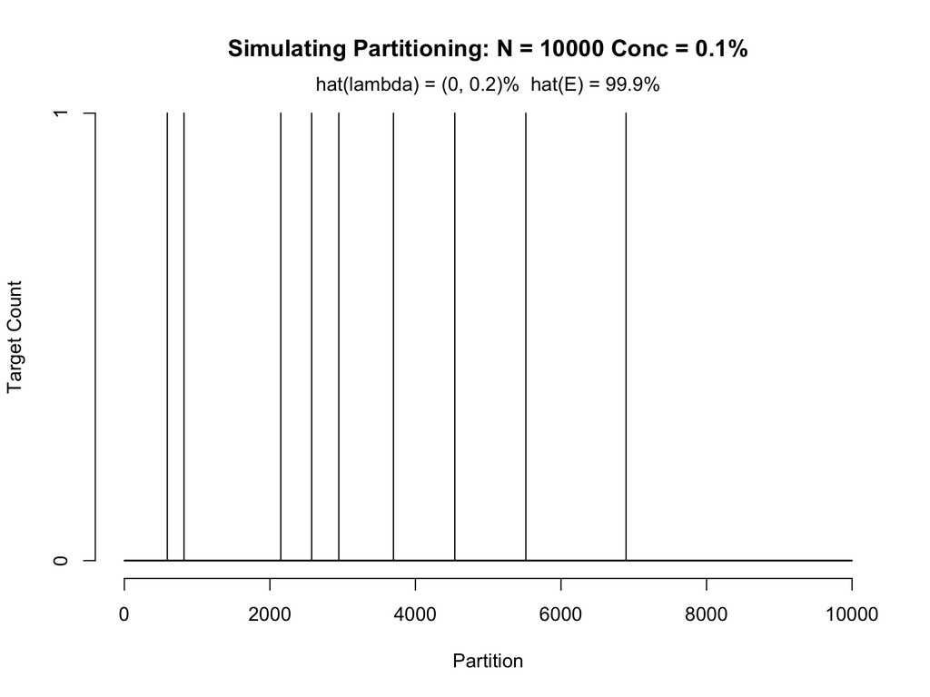

Figure 1.3: No Volume Variability, Conc =0.1%

```r
 # draw N
Conc = CONC
 # THIS IS NOT ENOUGH VARIABILITY
 # n_pos <- runif(n=N*Conc) * N

 # Should incorporate the subsampling variability
 # N is partition and sample size
 n_target <- rpois(n=1, lambda = N)
 n_pos <- runif(n=n_target*Conc) * N
 Conc_hist <- hist(n_pos, breaks=seq(from=0, to = N, len = N), plot=F)


E_hat <- mean(Conc_hist$counts == 0)
E_low <- E_hat - 2 * sqrt(E_hat * (1 - E_hat)/N)
E_hi <- E_hat + 2 * sqrt(E_hat * (1 - E_hat)/N)

lambda_hat <- - log(E_hat)
lambda_low <- - log(E_hi)
lambda_hi <- - log(E_low)

M_est <-  - N * log(E_hat)

plot(Conc_hist, main='',  ylab="Target Count", xlab = "Partition",
    xlim=c(1, 10000))

title(paste0("Simulating Partitioning: N = ", N, " Conc = ", 100*CONC, '%'))
mtext(side = 3, paste0(expression(hat(lambda)),  ' = (',
  round(100*lambda_low,1), ', ', round(100*lambda_hi,1), ')%',
  "  hat(E) = ", round(100*E_hat, 1), '%'))
```

```r
set.seed(101)
novolvar_conc_0p001_frm <- do.call("rbind", lapply(1:5000,
function(K)
{
 # THIS IS NOT ENOUGH VARIABILITY
 # n_pos <- runif(n=N*Conc) * N

 # Should incorporate the subsampling variability
 # N is partition and sample size
 n_target <- rpois(n=1, lambda = N)
 n_pos <- runif(n=n_target*Conc) * N
 Conc_hist <- hist(n_pos, breaks=seq(from=0, to = N, len = N), plot=F)

 #table(Conc_hist$counts)

 E_hat <- mean(Conc_hist$counts == 0)
 E_low <- E_hat - 2 * sqrt(E_hat * (1 - E_hat)/N)
 E_hi <- E_hat + 2 * sqrt(E_hat * (1 - E_hat)/N)

 lambda_hat <- - log(E_hat)
 lambda_low <- - log(E_hi)
 lambda_hi <- - log(E_low)

  # Interval according to ddPCR_ENGL_2019
  n_tot <- length(Conc_hist$counts)
  n_neg <- sum(Conc_hist$counts == 0)
  n_pos <- n_tot - n_neg
  lambda_low2 <- lambda_hat - 2 * sqrt(n_pos/(n_tot*n_neg))
  lambda_hi2 <- lambda_hat + 2 * sqrt(n_pos/(n_tot*n_neg))


 data.frame(sim=K, E_hat = E_hat, E_low, E_hi, lambda_hat, lambda_low, lambda_hi,
      lambda_low2, lambda_hi2)
}))
```

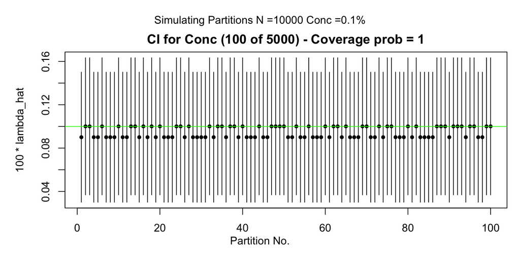

Figure 1.4: No Volume Variability, Conc = 0.001

```r
par(mfrow=c(1,1), mar=c(2, 5, 2, 1),oma=c(2,0,2,0))

with(novolvar_conc_0p001_frm[1:100,],
{
plot(1:100, 100*lambda_hat, pch=20, ylim = c(min(100*lambda_low), max(100*lambda_hi)), xlab="")
segments(x0=1:100, x1=1:100, y0=100*lambda_low, y1=100*lambda_hi)
abline(h=100*Conc, col='green')
}
)
lambda_coverage_prob <- with(novolvar_conc_0p001_frm,
mean(lambda_low < Conc & Conc < lambda_hi))

title(paste("CI for Conc (100 of 5000) - Coverage prob =",
   round(lambda_coverage_prob, 2)))

SKIP_E_HAT <- function() {
with(novolvar_conc_0p001_frm[1:100,],
{
plot(1:100, E_hat, pch=20, ylim = c(min(E_low), max(E_hi)), xlab="")
segments(x0=1:100, x1=1:100, y0=E_low, y1=E_hi)
abline(h=1-Conc, col='green')
}
)
E_coverage_prob <- with(novolvar_conc_0p001_frm,
mean(E_low < (1-Conc) & (1-Conc) < E_hi))

title(paste("Confidence intervals for Proportion Empty Titrations (100 of 5000) - Coverage prob =",
   round(E_coverage_prob, 2)))
}# SKIP_E_HAT

mtext(side=1, outer=T, "Partition No.")
mtext(side=3, outer=T, paste0("Simulating Partitions N =", N, " Conc =", 100*CONC, '%'))
```

## 1.4 ddPCR Data Analysis by GLM

In this section we carry out data analyses outlined in Dorazio et al. (2015) [6].

### Home

### Dilution Data Analysis

#### Home

#### Load the data

```r
dorazio_dilution_frm <- with(params,
data.table::fread(file.path(Dorazio_2015_supp_dir, Dorazio_dilution_file)))

dorazio_dilution_frm %<>%
dplyr::mutate(concF = paste0("C",
   as.numeric(as.factor(conc)))
 ) %>%
dplyr::group_by(concF) %>%
dplyr::mutate(rep = paste0('r', formatC(dplyr::row_number(), width=2, flag='0'))) %>%
dplyr::arrange(concF, rep) %>%
dplyr::relocate(concF, rep) %>% as.data.frame()

dorazio_dilution_frm %<>%
dplyr::rename(
   npos = npositive,
   ntot = ntotal) %>%
dplyr::mutate(
   nneg = ntot - npos
)

 # also add vol, which is needed later
 # constant volume (microliters) per droplet (physical constant)

dorazio_dilution_frm %<>%
dplyr::mutate(
  Vp = 0.91 / 1000,
  E = nneg / ntot,
  C = -log(E)/Vp
)
```

Annotate …

```r
 ########################################
 # Annotation
 ########################################

 # Option 3
grail_color <- c("#3B1C52","#94724F","#628592","#666666","#546741","#B73D27",
               "#D29A22","royalblue4","plum4","maroon4", "turquoise4", "tomato4")
col_vector <- rev(grail_color)


 # Option 2
suppressPackageStartupMessages(require(RColorBrewer))
qual_col_pals <- brewer.pal.info[brewer.pal.info$category == 'qual',]
col_vector <- unlist(mapply(brewer.pal, qual_col_pals$maxcolors, rownames(qual_col_pals)))
col_vector[4] <- 'red'
col_vector[8] <- 'darkgreen'

 # Option 1
KellyColors.vec <- c(
  "#222222", "#F3C300", "#875692", "#F38400", "#A1CAF1",
  "#BE0032", "#C2B280", "#848482", "#008856", "#E68FAC", "#0067A5",
  "#F99379", "#604E97", "#F6A600", "#B3446C", "#DCD300", "#882D17",
  "#8DB600", "#654522", "#E25822", "#2B3D26"
)
col_vector <- KellyColors.vec

 # recycle for more levels
 col_vector <- rep(col_vector, 3)

 Pch_v <- setdiff(1:50, 26:31)


 # concF
concFLegend_vec <- sort(unique(dorazio_dilution_frm$concF))
concFCol_vec <- col_vector[1:length(concFLegend_vec)]
names(concFCol_vec) <- concFLegend_vec

concFPch_vec <- Pch_v[1:length(concFLegend_vec)]
names(concFPch_vec) <- concFLegend_vec


 # rep
repLegend_vec <- sort(unique(dorazio_dilution_frm$rep))
repCol_vec <- col_vector[1:length(repLegend_vec)]
names(repCol_vec) <- repLegend_vec

repPch_vec <- Pch_v[1:length(repLegend_vec)]
names(repPch_vec) <- repLegend_vec
```

- Unequal slopes indicate that the relationship between `npositive` and `ntotal` cannot be reduced to the ratio of the two.

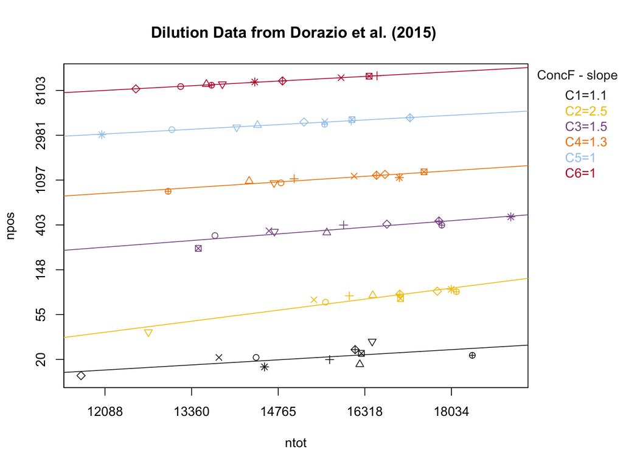

Figure 1.5: Dorazio Dilution Data

```r
par(mar=par("mar") + c(0, 0 , 0, 4))

with(dorazio_dilution_frm,
plot(x = log(ntot), y = log(npos),  log='',
     col = concFCol_vec[concF],
     pch = repPch_vec[rep],
    xaxt = 'n', yaxt = 'n', xlab='ntot', ylab='npos' )
)
with(dorazio_dilution_frm,
{
axis(side=1, at = pretty(log(ntot)), label = round(exp( pretty(log(ntot))), 0))
axis(side=2, at = pretty(log(npos)), label = round(exp( pretty(log(npos))), 0))
})

concF_dil_frm_lst <- split(dorazio_dilution_frm, dorazio_dilution_frm$concF)
concF_dil_lm_lst <- lapply(concF_dil_frm_lst, function(frm)
  lm(log(npos) ~  log(ntot), data = frm))


for(CC in names(concF_dil_lm_lst)) {
  dil_lm <- concF_dil_lm_lst[[CC]]
  abline(dil_lm, col = concFCol_vec[CC])
}

slopes_vec <- sapply(concF_dil_lm_lst, function(LM) coefficients(LM)[[2]])

old_par =  par(xpd = NA)

legend('topright', inset = c(-.2, 0), title = "ConcF - slope",
legend = paste0(names(slopes_vec), '=', round(slopes_vec, 1)),
text.col = concFCol_vec[names(slopes_vec)], bty='n')

par(old_par)

title("Dilution Data from Dorazio et al. (2015) ")
```

#### rePlot the data

- Replot the data in the way that reflects the fitted model.

```r
dorazio_byDil_frm <- dorazio_dilution_frm %>%
dplyr::group_by(concF) %>%
dplyr::summarize(
  Vp = median(Vp),
  conc = round(median(conc), 2),
  ntot_med = median(ntot),
  npos_med = median(npos),
  nneg_med = median(nneg),
  E_q1 = round(quantile(100*E, prob=1/4), 2),
  E_q3 = round(quantile(100*E, prob=3/4), 2),
  E_cv = (E_q3 - E_q1)/(E_q3 + E_q1),
  C_q1 = round(quantile(C, prob=1/4), 1),
  C_q3 = round(quantile(C, prob=3/4), 1),
  C_cv = (C_q3 - C_q1)/(C_q3 + C_q1),
  #E_iqr = paste0( E_q1, ', ', E_q3),
  #C_iqr = paste0( C_q1, ', ', C_q3)
) %>% as.data.frame()


dorazio_byDil_frm %>%
knitr::kable(
caption = "Dorazio Dilution Data - Summarized over reps"
) %>%
kableExtra::kable_styling(full_width = F)
```

Table 1.1: Dorazio Dilution Data - Summarized over reps

| concF | Vp | conc | ntot_med | npos_med | nneg_med | E_q1 | E_q3 | E_cv | C_q1 | C_q3 | C_cv |
| --- | --- | --- | --- | --- | --- | --- | --- | --- | --- | --- | --- |
| C1 | 0.00091 | 1.54 | 15902.0 | 21.0 | 15879.5 | 99.85 | 99.88 | 0.0001502 | 1.3 | 1.7 | 0.1333333 |
| C2 | 0.00091 | 6.14 | 16729.0 | 83.5 | 16644.0 | 99.48 | 99.53 | 0.0002512 | 5.2 | 5.7 | 0.0458716 |
| C3 | 0.00091 | 24.57 | 15770.0 | 377.5 | 15399.0 | 97.53 | 97.73 | 0.0010243 | 25.2 | 27.5 | 0.0436433 |
| C4 | 0.00091 | 98.29 | 15578.5 | 1145.5 | 14414.0 | 92.50 | 93.03 | 0.0028567 | 79.4 | 85.7 | 0.0381587 |
| C5 | 0.00091 | 393.15 | 15394.5 | 3906.5 | 11374.0 | 74.07 | 74.64 | 0.0038330 | 321.4 | 329.9 | 0.0130508 |
| C6 | 0.00091 | 1572.59 | 14107.0 | 9551.0 | 4580.5 | 32.15 | 32.97 | 0.0125921 | 1219.5 | 1246.9 | 0.0111093 |

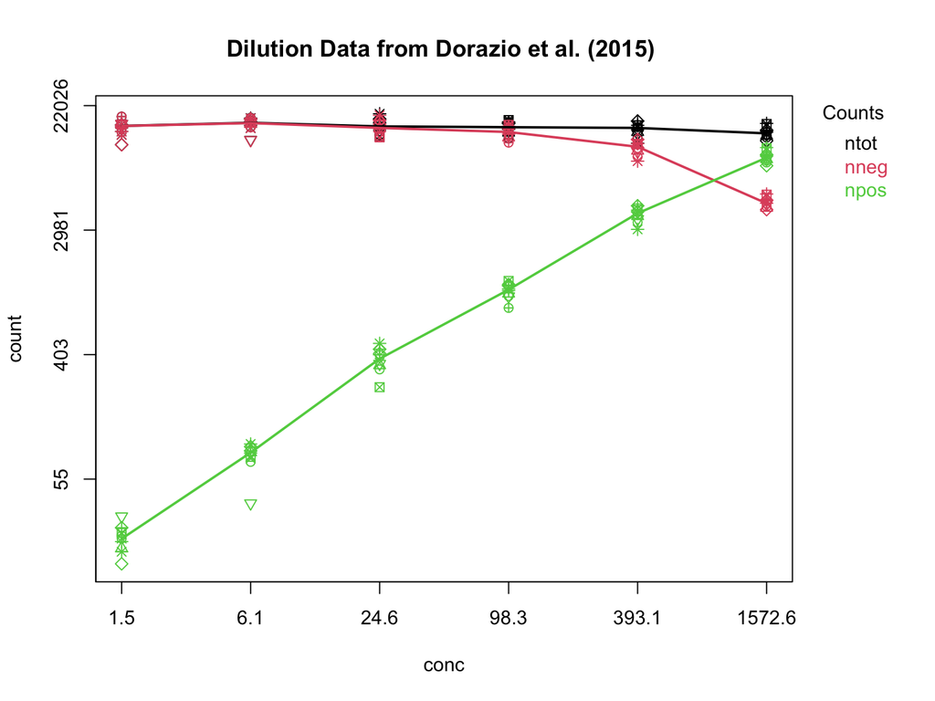

Figure 1.6: Dorazio Dilution Data - Counts: total, pos, neg

```r
par(mar=par("mar") + c(0, 0 , 0, 4))

with(dorazio_dilution_frm,
{
plot(x = log(conc), y = log(ntot),  log='', ylim=range(log(c(ntot, npos, nneg))),
     col = 1, ###concFCol_vec[concF],
     pch = repPch_vec[rep],
    xaxt = 'n', yaxt = 'n', xlab='conc', ylab='count')
points(log(conc), log(nneg),
       col = 2, ###concFCol_vec[concF],
       pch = repPch_vec[rep]
      )
points(log(conc), log(npos),
       col = 3, ###concFCol_vec[concF],
       pch = repPch_vec[rep]
      )
axis(side=2, at = pretty(log(c(ntot, npos, nneg))),
label = round(exp( pretty(log(c(ntot, npos, nneg)))), 0))
axis(side=1, at = log(unique(conc)), label = round(unique(conc), 1))

}
)

with(dorazio_byDil_frm, lines(log(conc), log(ntot_med), col = 1, lwd=2))
with(dorazio_byDil_frm, lines(log(conc), log(nneg_med), col = 2, lwd=2))
with(dorazio_byDil_frm, lines(log(conc), log(npos_med), col = 3, lwd=2))

old_par =  par(xpd = NA)

legend('topright', inset=c(-.15, 0), legend = c("ntot", "nneg", "npos"), text.col = 1:3,
bty='n', title="Counts", title.col = 1)

par(old_par)


title("Dilution Data from Dorazio et al. (2015) ")
```

#### reRePlot the data

- Replot the data in the way that reflects the fitted model.
  - only show negative and total counts as posiitive counts are at a different level and compress the figure.

```r
dorazio_byDil_frm <- dorazio_dilution_frm %>%
dplyr::group_by(concF) %>%
dplyr::summarize(
  Vp = median(Vp),
  conc = round(median(conc), 2),
  ntot_med = median(ntot),
  npos_med = median(npos),
  nneg_med = median(nneg),
  E_q1 = round(quantile(100*E, prob=1/4), 2),
  E_q3 = round(quantile(100*E, prob=3/4), 2),
  E_cv = round(100*(E_q3 - E_q1)/(E_q3 + E_q1), 3),
  C_q1 = round(quantile(C, prob=1/4), 1),
  C_q3 = round(quantile(C, prob=3/4), 1),
  C_cv = round(100*(C_q3 - C_q1)/(C_q3 + C_q1), 3),
  #E_iqr = paste0( E_q1, ', ', E_q3),
  #C_iqr = paste0( C_q1, ', ', C_q3)
) %>% as.data.frame()


dorazio_byDil_frm %>%
knitr::kable(
caption = "Dorazio Dilution Data - Summarized over reps"
) %>%
kableExtra::kable_styling(full_width = F)
```

Table 1.2: Dorazio Dilution Data - Summarized over reps

| concF | Vp | conc | ntot_med | npos_med | nneg_med | E_q1 | E_q3 | E_cv | C_q1 | C_q3 | C_cv |
| --- | --- | --- | --- | --- | --- | --- | --- | --- | --- | --- | --- |
| C1 | 0.00091 | 1.54 | 15902.0 | 21.0 | 15879.5 | 99.85 | 99.88 | 0.015 | 1.3 | 1.7 | 13.333 |
| C2 | 0.00091 | 6.14 | 16729.0 | 83.5 | 16644.0 | 99.48 | 99.53 | 0.025 | 5.2 | 5.7 | 4.587 |
| C3 | 0.00091 | 24.57 | 15770.0 | 377.5 | 15399.0 | 97.53 | 97.73 | 0.102 | 25.2 | 27.5 | 4.364 |
| C4 | 0.00091 | 98.29 | 15578.5 | 1145.5 | 14414.0 | 92.50 | 93.03 | 0.286 | 79.4 | 85.7 | 3.816 |
| C5 | 0.00091 | 393.15 | 15394.5 | 3906.5 | 11374.0 | 74.07 | 74.64 | 0.383 | 321.4 | 329.9 | 1.305 |
| C6 | 0.00091 | 1572.59 | 14107.0 | 9551.0 | 4580.5 | 32.15 | 32.97 | 1.259 | 1219.5 | 1246.9 | 1.111 |

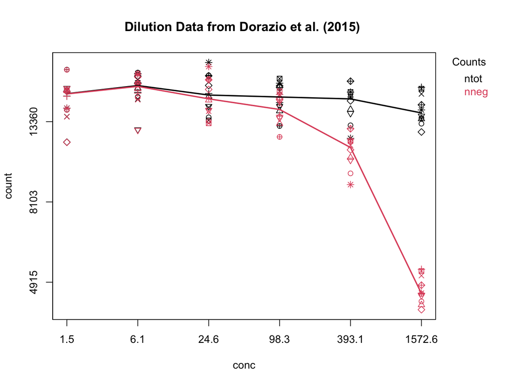

Figure 1.7: Dorazio Dilution Data

```r
par(mar=par("mar") + c(0, 0 , 0, 4))

with(dorazio_dilution_frm,
{
plot(x = log(conc), y = log(ntot),  log='',
     #ylim=pmax(c(log(500), 0), range(log(c(ntot, npos, nneg)))),
     ylim=range(log(c(ntot, nneg))),
     col = 1, ###concFCol_vec[concF],
     pch = repPch_vec[rep],
    xaxt = 'n', yaxt = 'n', xlab='conc', ylab='count')
points(log(conc), log(nneg),
       col = 2, ###concFCol_vec[concF],
       pch = repPch_vec[rep]
      )
axis(side=2, at = pretty(log(c(ntot, nneg))),
label = round(exp( pretty(log(c(ntot, nneg)))), 0))
axis(side=1, at = log(unique(conc)), label = round(unique(conc), 1))

}
)

with(dorazio_byDil_frm, lines(log(conc), log(ntot_med), col = 1, lwd=2))
with(dorazio_byDil_frm, lines(log(conc), log(nneg_med), col = 2, lwd=2))

old_par =  par(xpd = NA)

legend('topright', inset=c(-.15, 0), legend = c("ntot", "nneg"), text.col = 1:3,
bty='n', title="Counts", title.col = 1)

par(old_par)


title("Dilution Data from Dorazio et al. (2015) ")
```

#### cloglog model fit

- The complimentary log-log link:  
  Cloglog regression is an extension of the logistic regression model and is particularly useful when the probability of an event is very small or very large.
  - used in Dorazio et al.

```r
cloglog_fit <- glm(cbind(npos, nneg) ~ log(conc), family=binomial(link='cloglog'),
   offset = log(Vp), data = dorazio_dilution_frm)

summary(cloglog_fit)
```

```
Call:
glm(formula = cbind(npos, nneg) ~ log(conc), family = binomial(link = "cloglog"),
    data = dorazio_dilution_frm, offset = log(Vp))

Coefficients:
            Estimate Std. Error z value Pr(>|z|)
(Intercept) 0.045727   0.015839   2.887  0.00389 **
log(conc)   0.960953   0.002359 407.410  < 2e-16 ***
---
Signif. codes:  0 '***' 0.001 '**' 0.01 '*' 0.05 '.' 0.1 ' ' 1

(Dispersion parameter for binomial family taken to be 1)

    Null deviance: 345842.3  on 59  degrees of freedom
Residual deviance:    214.6  on 58  degrees of freedom
AIC: 691.04

Number of Fisher Scoring iterations: 3
```

```r
  # for manually extracting informantion from fit objects
beta.mle = cloglog_fit$coefficients
beta.vcv = vcov(cloglog_fit)
beta.se = sqrt(diag(beta.vcv))
alpha = 0.05  # significance level for confidence intervals
zcrit = qnorm(1-alpha/2)
beta.lowerCL = beta.mle - zcrit*beta.se
beta.upperCL = beta.mle + zcrit*beta.se
deviance = cloglog_fit$deviance
GOF = 1 - pchisq(deviance, df=nrow(dorazio_dilution_frm)-length(beta.mle))


 # Summarize results
beta.out = cbind(beta.mle, beta.se, beta.lowerCL, beta.upperCL)
dimnames(beta.out)[2] = list(c('MLE', 'SE', '2.5%', '97.5%'))

if(F)
print(beta.out)

 # Estimate concentration of each dilution
X <- with(dorazio_dilution_frm, model.matrix( ~ log(conc)))

X.pred <- unique(X)

lambda.est = rep(NA,dim(X.pred)[1])
lambda.lowerCL = rep(NA,dim(X.pred)[1])
lambda.upperCL = rep(NA,dim(X.pred)[1])
for (i in 1:dim(X.pred)[1]) {
    Xvec = matrix(X.pred[i,], ncol=1)
    loglambda.est = t(Xvec) %*% beta.mle
    loglambda.var = t(Xvec) %*% beta.vcv %*% Xvec
    lambda.est[i] = exp(loglambda.est)
    lambda.lowerCL[i] = exp(loglambda.est - zcrit*sqrt(loglambda.var))
    lambda.upperCL[i] = exp(loglambda.est + zcrit*sqrt(loglambda.var))
}

data.frame(lambda_est  = lambda.est,
           lambda_lcb = lambda.lowerCL,
           lambda_ucb = lambda.upperCL) %>%
knitr::kable(
caption = "cloglog fit estimates"
) %>%
kableExtra::kable_styling(full_width = F)
```

Table 1.3: cloglog fit estimates

| lambda_est | lambda_lcb | lambda_ucb |
| --- | --- | --- |
| 1.580886 | 1.535559 | 1.627550 |
| 5.990343 | 5.855228 | 6.128575 |
| 22.698801 | 22.324272 | 23.079612 |
| 86.011028 | 85.092405 | 86.939569 |
| 325.915768 | 323.967895 | 327.875351 |
| 1234.970556 | 1227.310318 | 1242.678604 |

```r
 # Alternatively, use model extraction methods

if(F)
cloglog_preds <- predict(cloglog_fit, newdata = new_data_frm, type = "response",
   se.fit = T)

 ### Return to this later
```

Residual plot

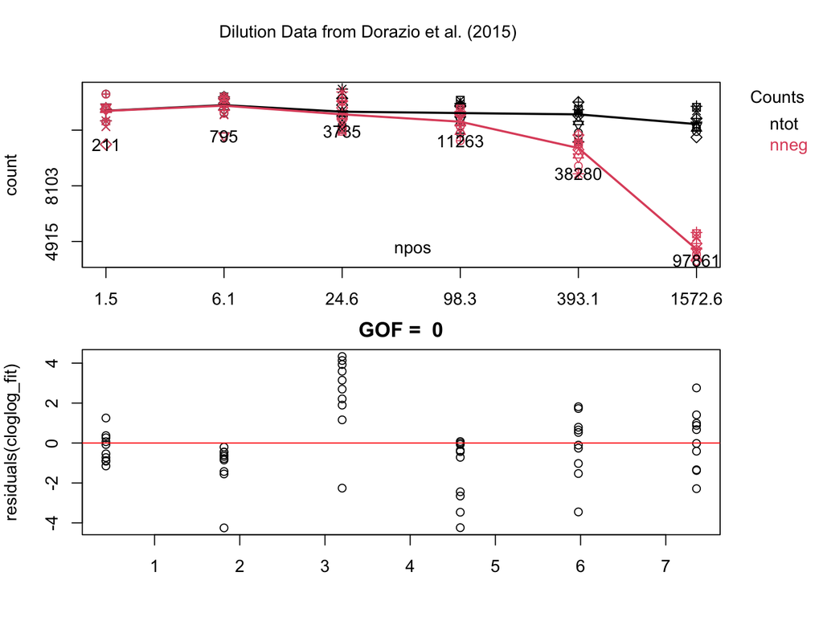

Figure 1.8: Dorazio Dilution Data

```r
par(mfrow= c(2, 1), mar = c(2, 4, 2, 1), oma=c(2, 0, 2, 4))

with(dorazio_dilution_frm,
{
plot(x = log(conc), y = log(ntot),  log='',
     #ylim=pmax(c(log(500), 0), range(log(c(ntot, npos, nneg)))),
     ylim=range(log(c(ntot, nneg))),
     col = 1, ###concFCol_vec[concF],
     pch = repPch_vec[rep],
    xaxt = 'n', yaxt = 'n', xlab='', ylab='count')
points(log(conc), log(nneg),
       col = 2, ###concFCol_vec[concF],
       pch = repPch_vec[rep]
      )
axis(side=2, at = pretty(log(c(ntot, nneg))),
label = round(exp( pretty(log(c(ntot, nneg)))), 0))
axis(side=1, at = log(unique(conc)), label = round(unique(conc), 1))
}
)

npos_vec <- with(dorazio_dilution_frm, sapply(split(npos, conc), sum))
nneg_vec <- with(dorazio_dilution_frm, sapply(split(nneg, conc), min))
with(dorazio_byDil_frm,
text(log(conc), log(nneg_vec), labels=npos_vec)
)
legend('bottom', legend = "npos", bty='n')

with(dorazio_byDil_frm, lines(log(conc), log(ntot_med), col = 1, lwd=2))
with(dorazio_byDil_frm, lines(log(conc), log(nneg_med), col = 2, lwd=2))

old_par =  par(xpd = NA)

legend('topright', inset=c(-.15, 0), legend = c("ntot", "nneg"), text.col = 1:3,
bty='n', title="Counts", title.col = 1)

par(old_par)

mtext(side=3, outer = T, "Dilution Data from Dorazio et al. (2015) ")

with(dorazio_dilution_frm,
{
plot(x = log(conc), y = residuals(cloglog_fit))
})
abline(h=0, col='red')
title(paste("GOF = ", GOF))
```

- A GOF of zero indicates that the model does not fit the data which is seen in the pattern of the residuals.
- In this case a one-group-at-a-time analysis may be preferable.

#### optim() model fit

**Come back to this later**

### CNV Analysis

**Come back to this later**

### Gene Expression Analysis

**Come back to this later**

## 1.5 `ddPCR` package

## 1.6 `twoddPCR` package

# 2 Appendix

## 2.1 Mathematical Results Relating to Binomial Variates

### Limit of non-detection

From HS calculus, or the Stack Exchange:

$$\begin{equation}
\lim\limits_{n \to \infty} \left( 1 + \frac{x}{n} \right)^n = e^x
\tag{2.1}
\end{equation}$$

1. Assume that we observe N iid Bernoulli trials each with probability of success `p`. In our example N is the number of fragments belonging to the conta estimation set, and `success` is observing a non-hom fragment. Then

$$\begin{equation}
P(X=0|N, p) = (1 - p)^N
\tag{2.2}
\end{equation}$$

The probability, $P(X=0|N, p)$ can be thought of as a likelihood of `p` given that X = 0 is observed. To obtain an $\alpha$ confidence interval for `p`, the following must hold:

$$\begin{equation}
(1 - p)^N = \alpha
\tag{2.3}
\end{equation}$$

### Rule of 3

When the binomial distribution is applicable, the Rule of 3 comes about this way.

Assume that we observe N iid Bernoulli trials each with probability of success `p`. In our example N is the number of fragments belonging to the conta estimation set, and `success` is observing a non-hom fragment. Then

$$\begin{equation}
P(X=0|N, p) = (1 - p)^N
\tag{2.2}
\end{equation}$$

The probability, $P(X=0|N, p)$ can be thought of as a likelihood of `p` given that X = 0 is observed. To obtain an $\alpha$ confidence interval for `p`, the following must hold:

$$\begin{equation}
(1 - p)^N = \alpha
\tag{2.3}
\end{equation}$$

We are focusing on X = 0 because the set {X = 0} is the identical same event as {The sample is not contaminated}.

A one sided confidence interval of level $\alpha$ is given by
$${p: (1 - p)^n > \alpha}$$
and solving for $p$ gives
$$p \le 1 - \alpha^{1/n}$$

By Taylor expansion,
$$\alpha^{1/n} = 1 + ln(\alpha)/n + [ln(\alpha)]^2/2n^2 + ...$$

Retaining just the linear term,
$$p \le - ln(\alpha)/n$$

In other words when X = 0, $-ln(\alpha)/n$ is an upper bound for p, which we may think of as a (**lower bound for**) Limit of Detection - we can never claim a lower p (but detection still needs to be demonstrated).

```r
data.frame(
  alpha = c(.05, .01, .001),
  `-ln(alpha)` = round(-log(c(.05, .01, .001)),2),
  check.names=F) %>%  t() %>%
knitr::kable(
caption = "X=0 UCB for p is -ln(alpha)/n"
) %>%
kableExtra::kable_styling(full_width = F)
```

Table 2.1: X=0 UCB for p is -ln(alpha)/n

| alpha | 0.05 | 0.01 | 0.001 |
| --- | --- | --- | --- |
| -ln(alpha) | 3.00 | 4.61 | 6.910 |

## 2.2 ddPCR - Pinheiro et al. (2012)

Pinheiro et al. (2012) [3] evaluate the ddPCR platform. The methodology is similar to Basu et al. (2017) [2]. The notation in this article is the following.

### Home

### 2.2.1 Notation

- Fraction of positive partitions $\Leftrightarrow$ sample concentration:

$$\begin{equation}
M = - ln \left( 1 - \frac{P}{R}\right)
\tag{2.4}
\end{equation}$$

where M is the average number of target molecules per partition, P is the number of partitions containing amplified product (not empty), and R is the number of partitions or reactions analyzed.

- Factors influencing variability:
  - R - the number of reeactions
  - the number of template molecules in the assay
  - partition volume (Vd)

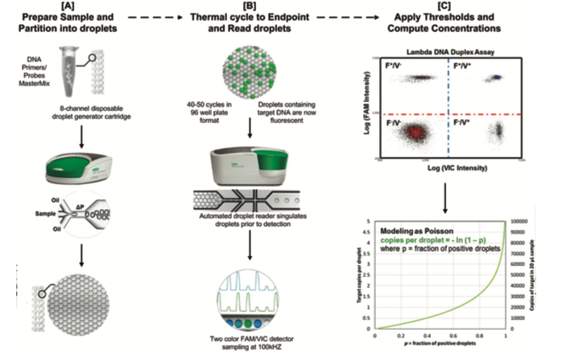

Figure 2.1: Schematic showing the ddPCR workflow (Anal. Chem. 2012, 84, 2, 1003-1011)

```r
knitr::include_graphics("img/Pinheiro_2012_Fig1.png")
```

### 2.2.2 Experimental Design

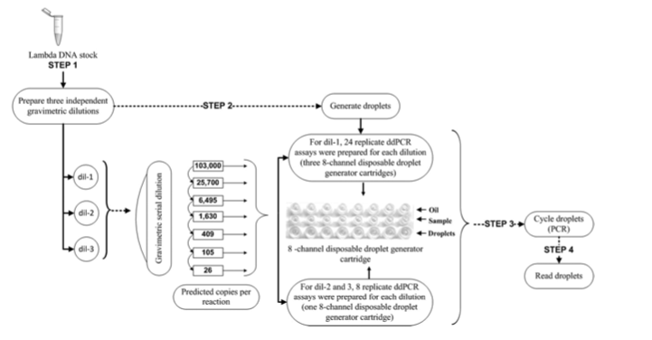

Figure 2.2: Schematic diagram of experimental design for assessing linearity and precision.(Anal. Chem. 2012, 84, 2, 1003-1011)

```r
knitr::include_graphics("img/Pinheiro_2012_Fig2.png")
```

- DNA were prepared using a gravimetric protocol to minimize the uncertainty due to pipetting.
- The ddPCR reagents, except DNA, were premixed and the final reaction mix was prepared gravimetrically by combining the DNA and PCR components (Supporting Information S-1).

### 2.2.3 Linearity and Precision

*Linearity and Precision over the Theoretical Dynamic Range of ddPCR Instrument.

- Three independent **gravimetric serial dilutions** of Lambda DNA were prepared to produce three sets of seven solutions containing an average of (based on absorbance measurements)
  - 26, 105, 409, 1 630, 6 495, 25 700, and 103 000 predicted copies of Lambda DNA per 20 μL ddPCR
- For two of the serial dilution sets (gravimetric dilution series 2 and 3), eight replicate ddPCRs were prepared from a single eight-channel droplet generator cartridge for each of the seven solutions.
- For gravimetric dilution series 1, 24 replicate ddPCRs were prepared from three eight-channel droplet generator cartridges for each of the seven solutions.
- The ddPCRs were analyzed using assay 2 under simplex conditions. A complete eight channel cartridge of NTC was prepared by adding 1× TE0.1 buffer in place of DNA template.
- NTCs showed alow-level background signal of approximately three positive droplets per NTC assay, which could possibly be attributed to low-level template contamination during the preparation of the reaction mixture.

#### 2.2.3.1 Comparison of DNA Concentration and Ratio Measurements

- Using Two Different dPCR Formats under Simplex and Duplex Conditions.

# 3 References

- google statistics of balls in boxes and bns
- [wiki Balls into bins problem](https://en.wikipedia.org/wiki/Balls_into_bins_problem).

1.

Yu, B., and Kumbier, K. (2018). Artificial intelligence and statistics. Frontiers of Information Technology & Electronic Engineering *19*, 6–9. Available at: https://doi.org/10.1631/FITEE.1700813.

2.

Basu, A.S. (2017). Digital assays part i: Partitioning statistics and digital PCR. SLAS Technology *22*, 369–386. Available at: https://www.sciencedirect.com/science/article/pii/S2472630322013334.

3.

Pinheiro, L.B., Coleman, V.A., Hindson, C.M., Herrmann, J., Hindson, B.J., Bhat, S., and Emslie, K.R. (2012). Evaluation of a droplet digital polymerase chain reaction format for DNA copy number quantification. Anal Chem *84*, 1003–1011.

4.

Kreutz, J.E., Munson, T., Huynh, T., Shen, F., Du, W., and Ismagilov, R.F. (2011). Theoretical design and analysis of multivolume digital assays with wide dynamic range validated experimentally with microfluidic digital PCR. Anal Chem *83*, 8158–8168.

5.

Dube, S., Qin, J., and Ramakrishnan, R. (2008). Mathematical analysis of copy number variation in a DNA sample using digital PCR on a nanofluidic device. PLoS One *3*, e2876.

6.

Dorazio, R.M., and Hunter, M.E. (2015). Statistical models for the analysis and design of digital polymerase chain reaction (dPCR) experiments. Analytical Chemistry *87*, 10886–10893. Available at: https://doi.org/10.1021/acs.analchem.5b02429.

7.

Burdukiewicz, M., Rödiger, S., Sobczyk, P., Menschikowski, M., Schierack, P., and Mackiewicz, P. (2016). Methods for comparing multiple digital PCR experiments. Biomol Detect Quantif *9*, 14–19.

8.

Uhlig, S., and Gowik, P. (2018). Efficient estimation of the limit of detection and the relative limit of detection along with their reproducibility in the validation of qualitative microbiological methods by means of generalized linear mixed models. Journal of Consumer Protection and Food Safety *13*, 79–87. Available at: https://doi.org/10.1007/s00003-017-1130-0.

9.

Loskyll, M., Podbiel, D., Guber, A., and Hoffmann, J. (2023). Partitioning and subsampling statistics in compartment-based quantification methods. PLoS One *18*, e0285784.

10.

Jacobs, B.K., Goetghebeur, E., and Clement, L. (2014). Impact of variance components on reliability of absolute quantification using digital PCR. BMC Bioinformatics *15*, 283. Available at: https://doi.org/10.1186/1471-2105-15-283.

11.

Group, T. dMIQE, and Huggett, J.F. (2020). The digital MIQE guidelines update: Minimum information for publication of quantitative digital PCR experiments for 2020. Clinical Chemistry *66*, 1012–1029. Available at: https://doi.org/10.1093/clinchem/hvaa125.

12.

Debski, P.R., and Garstecki, P. (2016). Designing and interpretation of digital assays: Concentration of target in the sample and in the source of sample. Biomolecular Detection and Quantification *10*, 24–30. Available at: https://www.sciencedirect.com/science/article/pii/S2214753516300079.

13.

Majumdar, N., Wessel, T., and Marks, J. (2015). Digital PCR modeling for maximal sensitivity, dynamic range and measurement precision. PLOS ONE *10*, e0118833–. Available at: https://doi.org/10.1371/journal.pone.0118833.

14.

Chen, Y., De Spiegelaere, W., Trypsteen, W., Gleerup, D., Vandesompele, J., and Thas, O. (2023). Flexible methods for standard error calculation in digital PCR experiments. bioRxiv, 2023.09.06.556592. Available at: http://biorxiv.org/content/early/2023/09/06/2023.09.06.556592.abstract.

15.

S, P., G, B., M, B., P, C., M, D.G., M, D.L., E, D., D, D., R, E., A, H.-J., *et al.* (2019). Overview and recommendations for the application of digital PCR.

16.

Tellinghuisen, J. (2020). dPCR vs. qPCR: The role of poisson statistics at low concentrations. Analytical biochemistry *611*, 113946.

17.

Whale, A.S., Cowen, S., Foy, C.A., and Huggett, J.F. (2013). Methods for applying accurate digital PCR analysis on low copy DNA samples. PLoS One *8*, e58177.

18.

Quan, P.-L., Sauzade, M., and Brouzes, E. (2018). dPCR: A technology review. Sensors (Basel) *18*.

19.

Taylor, S.C., Laperriere, G., and Germain, H. (2017). Droplet digital PCR versus qPCR for gene expression analysis with low abundant targets: From variable nonsense to publication quality data. Scientific Reports *7*, 2409. Available at: https://doi.org/10.1038/s41598-017-02217-x.

20.

Stephens, O.W., Meißner, T., and Weinhold, N. (2018). Detection of cross-sample contamination in multiple myeloma samples and sequencing data. Methods Mol Biol *1792*, 147–155.

21.

Attali, D., Bidshahri, R., Haynes, C., and Bryan, J. (2016). Ddpcr: An r package and web application for analysis of droplet digital PCR data. F1000Res *5*, 1411.

22.

Brink, B.G., Meskas, J., and Brinkman, R.R. (2018). ddPCRclust: An r package and shiny app for automated analysis of multiplexed ddPCR data. Bioinformatics *34*, 2687–2689. Available at: https://doi.org/10.1093/bioinformatics/bty136.

**R version 4.4.2 (2024-10-31)**

**Platform:** x86_64-apple-darwin20

**locale:** en_US.UTF-8||en_US.UTF-8||en_US.UTF-8||C||en_US.UTF-8||en_US.UTF-8

**attached base packages:** *stats*, *graphics*, *grDevices*, *utils*, *datasets*, *methods* and *base*

**other attached packages:** *RColorBrewer(v.1.1-3)*, *magrittr(v.2.0.3)*, *dplyr(v.1.1.4)*, *plyr(v.1.8.9)*, *data.table(v.1.16.4)*, *bookdown(v.0.41)*, *knitr(v.1.49)* and *rmarkdown(v.2.29)*

**loaded via a namespace (and not attached):** *vctrs(v.0.6.5)*, *cli(v.3.6.3)*, *rlang(v.1.1.4)*, *xfun(v.0.49)*, *generics(v.0.1.3)*, *jsonlite(v.1.8.9)*, *glue(v.1.8.0)*, *htmltools(v.0.5.8.1)*, *sass(v.0.4.9)*, *pander(v.0.6.5)*, *evaluate(v.1.0.1)*, *jquerylib(v.0.1.4)*, *tibble(v.3.2.1)*, *fastmap(v.1.2.0)*, *yaml(v.2.3.10)*, *lifecycle(v.1.0.4)*, *compiler(v.4.4.2)*, *pkgconfig(v.2.0.3)*, *Rcpp(v.1.0.13-1)*, *digest(v.0.6.37)*, *R6(v.2.5.1)*, *tidyselect(v.1.2.1)*, *pillar(v.1.10.0)*, *bslib(v.0.8.0)*, *tools(v.4.4.2)* and *cachem(v.1.1.0)*

- WRKDIR = /Users/fcollin/Documents/Projects/ddPCR
- FN = _M1A-cf_ddPCR_seq
- Scripts = Scripts
- RUN DATE = Sat Jan 4 00:16:25 2025
[^1]: See mention by [Andrew Gilman](https://statmodeling.stat.columbia.edu/2017/12/07/bin-yu-karl-kumbier-artificial-intelligence-statistic/)
[^2]: E is also used to denote the proportions of empty partitions
[^3]: Should read `95% confidence that the calculated uncertainty covers the measurement, or true value being estimated by measurement.